# 重賞レース予測レポート【レース終了】

作成日時: 2025/11/16 16:16:58

☞ [マニュアル(pdf)](https://ryutoro-galois.github.io/keiba-predictor/manual/manual.pdf)

☞ 過去5年の同一レース結果: [2024年](https://ryutoro-galois.github.io/keiba-predictor/report/PredResult_2024y_raceDate_20241109_20241110.html), [2023年](https://ryutoro-galois.github.io/keiba-predictor/report/PredResult_2023y_raceDate_20231111_20231112.html), [2022年](https://ryutoro-galois.github.io/keiba-predictor/report/PredResult_2022y_raceDate_20221112_20221113.html), [2021年](https://ryutoro-galois.github.io/keiba-predictor/report/PredResult_2021y_raceDate_20211113_20211114.html), [2020年](https://ryutoro-galois.github.io/keiba-predictor/report/PredResult_2020y_raceDate_20201114_20201115.html)

☞ 過去4週間の別レース結果: [1週前(11/8-9)](https://ryutoro-galois.github.io/keiba-predictor/report/PredResult_2025y_raceDate_20251108_20251109.html), [2週前(11/1-2)](https://ryutoro-galois.github.io/keiba-predictor/report/PredResult_2025y_raceDate_20251101_20251102.html), [3週前(10/25-26)](https://ryutoro-galois.github.io/keiba-predictor/report/PredResult_2025y_raceDate_20251025_20251026.html), [4週前(10/18-19)](https://ryutoro-galois.github.io/keiba-predictor/report/PredResult_2025y_raceDate_20251018_20251019.html)

☞ netkeiba: [武蔵野ステークス(GⅢ))](https://race.netkeiba.com/race/result.html?race_id=202505050311&rf=race_submenu), [デイリー杯2歳ステークス(GⅡ)](https://race.netkeiba.com/race/result.html?race_id=202508040311&rf=race_submenu), [エリザベス女王杯(GⅠ)](https://race.netkeiba.com/race/result.html?race_id=202508040411&rf=race_submenu)

☞ レース結果(csv): [11/15-16](https://ryutoro-galois.github.io/keiba-predictor/csv/race_result_20251115_20251116.csv)

## 【レース結果(1)】人気と着順の関係

### 【武蔵野ステークス(2025/11/15(土))】

【武蔵野ステークス(GⅢ)】  
2025/11/15(土), 05_東京, ダ左1600m

[interactive chart not shown]

### 【デイリー杯2歳ステークス(2025/11/15(土))】

【デイリー杯2歳ステークス(GⅡ)】  
2025/11/15(土), 08_京都, 芝右外1600m

[interactive chart not shown]

### 【エリザベス女王杯(2025/11/16(日))】

【エリザベス女王杯(GⅠ)】  
2025/11/16(日), 08_京都, 芝右外2200m

[interactive chart not shown]

## 【レース結果(2)】コーナー通過順位

### 【武蔵野ステークス(2025/11/15(土))】

【武蔵野ステークス(GⅢ)】  
2025/11/15(土), 05_東京, ダ左1600m

[interactive chart not shown]

### 【デイリー杯2歳ステークス(2025/11/15(土))】

【デイリー杯2歳ステークス(GⅡ)】  
2025/11/15(土), 08_京都, 芝右外1600m

[interactive chart not shown]

### 【エリザベス女王杯(2025/11/16(日))】

【エリザベス女王杯(GⅠ)】  
2025/11/16(日), 08_京都, 芝右外2200m

[interactive chart not shown]

## 0. 推し馬予測 (AI予測)

### 【武蔵野ステークス(GⅢ) 2025/11/15(土)】

- 本命(◎): 1-3着内確率(勝負強さ)が1位の馬
- 対抗(◯): 1-3着内確率が2-N位(20%程度以上)の中で予測タイムが最も速い馬
- 3番手(▲): 1-3着内確率が2-N位(20%程度以上)のでダークホース確率が最も高い馬
- 穴: ダークホース確率が上位1-M位(40%程度以上)の中で1-3着内確率が最も高い馬

| 推し馬 | 枠番 | 馬番 | 人気 | オッズ | 馬名 | 騎手 | 調教師 | 予測タイム(sec) | 1_順位 | 1-3着内確率(%) | 2_順位 | ﾀﾞｰｸﾎｰｽ確率(%) | 3_順位 |
| --- | --- | --- | --- | --- | --- | --- | --- | --- | --- | --- | --- | --- | --- |
| 本命(◎) | 6 | 11 | 2 | 3.8 | オメガギネス | 岩田康誠 | 安田翔伍 | 100.5 | 10 | 59.7 | 1 | 0.6 | 14 |
| 対抗(◯) | 8 | 16 | 3 | 4.5 | ルクソールカフェ | Ｄ．レーン | 堀宣行 | 98.0 | 2 | 50.0 | 2 | 0.5 | 15 |
| 3番手(▲) | 5 | 9 | 9 | 28.5 | マテンロウコマンド | 松山弘平 | 長谷川浩大 | 98.4 | 4 | 20.9 | 6 | 29.2 | 4 |
| 穴 | 4 | 7 | 13 | 104.7 | アドマイヤデイトナ | 横山武史 | 加藤征弘 | 98.4 | 5 | 9.9 | 10 | 41.6 | 1 |

### 【デイリー杯2歳ステークス(GⅡ) 2025/11/15(土)】

- 本命(◎): 1-3着内確率(勝負強さ)が1位の馬
- 対抗(◯): 1-3着内確率が2-N位(20%程度以上)の中で予測タイムが最も速い馬
- 3番手(▲): 1-3着内確率が2-N位(20%程度以上)のでダークホース確率が最も高い馬
- 穴: ダークホース確率が上位1-M位(40%程度以上)の中で1-3着内確率が最も高い馬

| 推し馬 | 枠番 | 馬番 | 人気 | オッズ | 馬名 | 騎手 | 調教師 | 予測タイム(sec) | 1_順位 | 1-3着内確率(%) | 2_順位 | ﾀﾞｰｸﾎｰｽ確率(%) | 3_順位 |
| --- | --- | --- | --- | --- | --- | --- | --- | --- | --- | --- | --- | --- | --- |
| 本命(◎) | 5 | 5 | 3 | 3.8 | キャンディード | 北村友一 | 松下武士 | 108.1 | 8.0 | 23.9 | 1 | 1.6 | 6 |
| 対抗(◯) | 6 | 6 | 1 | 2.6 | アドマイヤクワッズ | 坂井瑠星 | 友道康夫 | 93.2 | 1.5 | 18.1 | 3 | 0.7 | 7 |
| 3番手(▲) | 1 | 1 | 6 | 22.5 | エイシンディード | 高杉吏麒 | 大久保龍志 | 107.6 | 4.0 | 12.1 | 4 | 40.7 | 3 |
| 穴 | 2 | 2 | 8 | 37.2 | マイケルバローズ | 岩田望来 | 上村洋行 | 107.6 | 4.0 | 9.8 | 7 | 47.3 | 1 |

### 【エリザベス女王杯(GⅠ) 2025/11/16(日)】

- 本命(◎): 1-3着内確率(勝負強さ)が1位の馬
- 対抗(◯): 1-3着内確率が2-N位(20%程度以上)の中で予測タイムが最も速い馬
- 3番手(▲): 1-3着内確率が2-N位(20%程度以上)のでダークホース確率が最も高い馬
- 穴: ダークホース確率が上位1-M位(40%程度以上)の中で1-3着内確率が最も高い馬

| 推し馬 | 枠番 | 馬番 | 人気 | オッズ | 馬名 | 騎手 | 調教師 | 予測タイム(sec) | 1_順位 | 1-3着内確率(%) | 2_順位 | ﾀﾞｰｸﾎｰｽ確率(%) | 3_順位 |
| --- | --- | --- | --- | --- | --- | --- | --- | --- | --- | --- | --- | --- | --- |
| 本命(◎) | 4 | 7 | 1 | 2.3 | レガレイラ | 戸崎圭太 | 木村哲也 | 132.3 | 1.5 | 35.0 | 1 | 0.6 | 15 |
| 対抗(◯) | 7 | 13 | 3 | 6.2 | ココナッツブラウン | 北村友一 | 上村洋行 | 132.3 | 1.5 | 23.3 | 4 | 0.5 | 16 |
| 3番手(▲) | 5 | 9 | 12 | 44.1 | ボンドガール | 津村明秀 | 手塚貴久 | 135.4 | 4.0 | 26.3 | 2 | 54.9 | 3 |
| 穴 | 7 | 14 | 16 | 145.6 | ケリフレッドアスク | 岩田康誠 | 藤原英昭 | 138.2 | 11.0 | 12.2 | 10 | 63.8 | 1 |

## 1. 予測チャート (タイム/勝負強さ)

### 【武蔵野ステークス(GⅢ)】

2025/11/15(土), 05_東京, ダ左1600m

[interactive chart not shown]

### 【デイリー杯2歳ステークス(GⅡ)】

2025/11/15(土), 08_京都, 芝右外1600m

[interactive chart not shown]

### 【エリザベス女王杯(GⅠ)】

2025/11/16(日), 08_京都, 芝右外2200m

[interactive chart not shown]

## 2. オッズモニタリング (毎時)

### 【武蔵野ステークス】

[interactive chart not shown]

### 【デイリー杯2歳ステークス】

[interactive chart not shown]

### 【エリザベス女王杯】

[interactive chart not shown]

## 3. 出馬表

### 【武蔵野ステークス 2025/11/15(土) 】

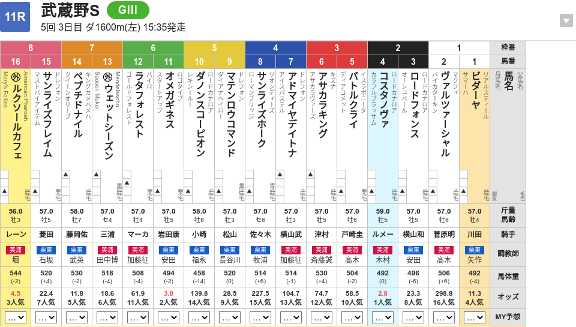

### 【デイリー杯2歳ステークス 2025/11/15(土) 】

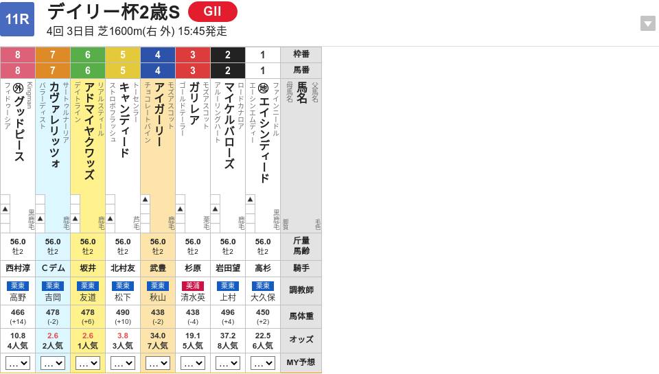

### 【エリザベス女王杯 2025/11/16(日) 】

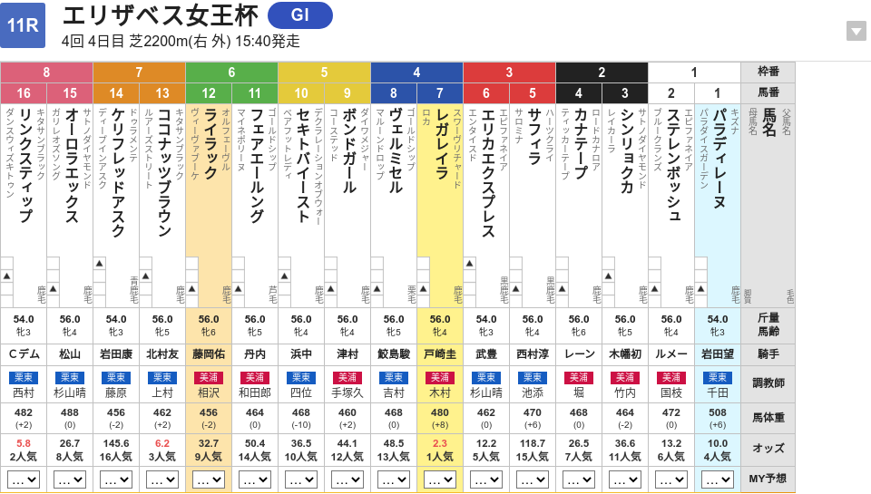

## 4. 単勝予測結果

### 【武蔵野ステークス(GⅢ) 2025/11/15(土)】

| 枠番 | 馬番 | 人気 | オッズ | 馬名 | 騎手 | 調教師 | 予測タイム(sec) | 1_順位 | 1-3着内確率(%) | 2_順位 | ﾀﾞｰｸﾎｰｽ確率(%) | 3_順位 |
| --- | --- | --- | --- | --- | --- | --- | --- | --- | --- | --- | --- | --- |
| 1 | 1 | 4 | 11.3 | ビダーヤ | 川田将雅 | 矢作芳人 | 99.3 | 8 | 35.2 | 3 | 1.5 | 12 |
| 1 | 2 | 16 | 298.8 | ヴァルツァーシャル | 菅原明良 | 高木登 | 100.6 | 11 | 3.8 | 15 | 7.0 | 8 |
| 2 | 3 | 8 | 23.3 | ロードフォンス | 横山和生 | 安田翔伍 | 100.8 | 13 | 13.1 | 7 | 1.5 | 11 |
| 2 | 4 | 1 | 2.8 | コスタノヴァ | Ｃ．ルメール | 木村哲也 | 93.8 | 1 | 10.0 | 9 | 0.4 | 16 |
| 3 | 5 | 10 | 58.5 | バトルクライ | 戸崎圭太 | 高木登 | 101.7 | 14 | 3.6 | 16 | 22.1 | 5 |
| 3 | 6 | 12 | 74.7 | アサカラキング | 津村明秀 | 斎藤誠 | 102.0 | 15 | 4.2 | 14 | 41.5 | 2 |
| 4 | 7 | 13 | 104.7 | アドマイヤデイトナ | 横山武史 | 加藤征弘 | 98.4 | 5 | 9.9 | 10 | 41.6 | 1 |
| 4 | 8 | 15 | 227.5 | サンライズホーク | 佐々木大輔 | 牧浦充徳 | 100.6 | 12 | 7.5 | 13 | 9.2 | 7 |
| 5 | 9 | 9 | 28.5 | マテンロウコマンド | 松山弘平 | 長谷川浩大 | 98.4 | 4 | 20.9 | 6 | 29.2 | 4 |
| 5 | 10 | 14 | 139.8 | ダノンスコーピオン | 小崎綾也 | 福永祐一 | 102.2 | 16 | 7.9 | 12 | 10.4 | 6 |

[output cut: 6 more lines]

### 【デイリー杯2歳ステークス(GⅡ) 2025/11/15(土)】

| 枠番 | 馬番 | 人気 | オッズ | 馬名 | 騎手 | 調教師 | 予測タイム(sec) | 1_順位 | 1-3着内確率(%) | 2_順位 | ﾀﾞｰｸﾎｰｽ確率(%) | 3_順位 |
| --- | --- | --- | --- | --- | --- | --- | --- | --- | --- | --- | --- | --- |
| 1 | 1 | 6 | 22.5 | エイシンディード | 高杉吏麒 | 大久保龍志 | 107.6 | 4.0 | 12.1 | 4 | 40.7 | 3 |
| 2 | 2 | 8 | 37.2 | マイケルバローズ | 岩田望来 | 上村洋行 | 107.6 | 4.0 | 9.8 | 7 | 47.3 | 1 |
| 3 | 3 | 5 | 19.1 | ガリレア | 杉原誠人 | 清水英克 | 107.7 | 6.0 | 11.3 | 5 | 34.9 | 4 |
| 4 | 4 | 7 | 34.0 | アイガーリー | 武豊 | 秋山真一郎 | 107.6 | 4.0 | 9.3 | 8 | 45.5 | 2 |
| 5 | 5 | 3 | 3.8 | キャンディード | 北村友一 | 松下武士 | 108.1 | 8.0 | 23.9 | 1 | 1.6 | 6 |
| 6 | 6 | 1 | 2.6 | アドマイヤクワッズ | 坂井瑠星 | 友道康夫 | 93.2 | 1.5 | 18.1 | 3 | 0.7 | 7 |
| 7 | 7 | 2 | 2.6 | カヴァレリッツォ | Ｃ．デムーロ | 吉岡辰弥 | 93.2 | 1.5 | 19.2 | 2 | 0.7 | 8 |
| 8 | 8 | 4 | 10.8 | グッドピース | 西村淳也 | 高野友和 | 107.9 | 7.0 | 10.2 | 6 | 1.9 | 5 |

### 【エリザベス女王杯(GⅠ) 2025/11/16(日)】

| 枠番 | 馬番 | 人気 | オッズ | 馬名 | 騎手 | 調教師 | 予測タイム(sec) | 1_順位 | 1-3着内確率(%) | 2_順位 | ﾀﾞｰｸﾎｰｽ確率(%) | 3_順位 |
| --- | --- | --- | --- | --- | --- | --- | --- | --- | --- | --- | --- | --- |
| 1 | 1 | 4 | 10.0 | パラディレーヌ | 岩田望来 | 千田輝彦 | 139.2 | 12.5 | 21.8 | 5 | 1.5 | 12 |
| 1 | 2 | 6 | 13.2 | ステレンボッシュ | Ｃ．ルメール | 国枝栄 | 138.1 | 9.5 | 19.4 | 7 | 1.7 | 11 |
| 2 | 3 | 11 | 36.6 | シンリョクカ | 木幡初也 | 竹内正洋 | 141.4 | 14.0 | 5.5 | 15 | 32.7 | 6 |
| 2 | 4 | 7 | 26.5 | カナテープ | Ｄ．レーン | 堀宣行 | 137.6 | 7.0 | 12.5 | 9 | 1.1 | 13 |
| 3 | 5 | 15 | 118.7 | サフィラ | 西村淳也 | 池添学 | 138.1 | 9.5 | 9.1 | 13 | 62.6 | 2 |
| 3 | 6 | 5 | 12.2 | エリカエクスプレス | 武豊 | 杉山晴紀 | 139.2 | 12.5 | 21.8 | 6 | 1.7 | 10 |
| 4 | 7 | 1 | 2.3 | レガレイラ | 戸崎圭太 | 木村哲也 | 132.3 | 1.5 | 35.0 | 1 | 0.6 | 15 |
| 4 | 8 | 13 | 48.5 | ヴェルミセル | 鮫島克駿 | 吉村圭司 | 136.6 | 5.0 | 10.2 | 12 | 36.2 | 5 |
| 5 | 9 | 12 | 44.1 | ボンドガール | 津村明秀 | 手塚貴久 | 135.4 | 4.0 | 26.3 | 2 | 54.9 | 3 |
| 5 | 10 | 10 | 36.5 | セキトバイースト | 浜中俊 | 四位洋文 | 137.3 | 6.0 | 8.2 | 14 | 38.0 | 4 |

[output cut: 6 more lines]

## 5. 人気と着順の乖離率推移

### 【武蔵野ステークス_1996y_2019y】

[interactive chart not shown]

### 【デイリー杯2歳ステークス_2001y_2019y】

[interactive chart not shown]

### 【エリザベス女王杯_1990y_2019y】

[interactive chart not shown]

### 【武蔵野ステークス_1996y_2019y】

| No | 開催年 | 不整合率(%) | 頭数 | 人気別着順(1-3位) | 人気別着順(全体) |
| --- | --- | --- | --- | --- | --- |
| 24 | 2019 | 59.5 | 16頭 | 9-8-13 | 9\|8\|13\|16\|3\|12\|2\|4\|7\|5\|1\|14\|11\|6\|10\|15 |
| 23 | 2018 | 19.1 | 16頭 | 1-7-2 | 1\|7\|2\|5\|14\|4\|3\|6\|9\|8\|13\|10\|16\|12\|15\|11 |
| 22 | 2017 | 52.3 | 16頭 | 6-8-15 | 6\|8\|15\|7\|2\|9\|3\|12\|4\|10\|14\|1\|5\|11\|13\|16 |
| 21 | 2016 | 39.3 | 16頭 | 8-2-6 | 8\|2\|6\|4\|10\|14\|1\|11\|3\|5\|13\|9\|7\|12\|16\|15 |
| 20 | 2015 | 34.1 | 14頭 | 2-5-1 | 2\|5\|1\|6\|4\|7\|12\|9\|8\|14\|3\|10\|13\|11 |
| 19 | 2014 | 27.8 | 16頭 | 7-1-11 | 7\|1\|11\|12\|4\|2\|13\|3\|10\|6\|14\|8\|16\|9\|5\|15 |
| 18 | 2013 | 23.8 | 16頭 | 1-3-7 | 1\|3\|7\|2\|15\|6\|4\|13\|14\|11\|5\|10\|8\|12\|16\|9 |
| 17 | 2012 | 39.3 | 16頭 | 1-4-6 | 1\|4\|6\|8\|9\|3\|5\|12\|15\|11\|7\|13\|14\|10\|2\|16 |
| 16 | 2011 | 39.3 | 16頭 | 4-1-3 | 4\|1\|3\|8\|9\|10\|5\|6\|2\|13\|15\|7\|12\|14\|16\|11 |
| 15 | 2010 | 62.5 | 16頭 | 6-4-9 | 6\|4\|9\|2\|14\|5\|3\|10\|12\|11\|8\|7\|15\|13\|1\|16 |

[output cut: 14 more lines]

### 【デイリー杯2歳ステークス_2001y_2019y】

| No | 開催年 | 不整合率(%) | 頭数 | 人気別着順(1-3位) | 人気別着順(全体) |
| --- | --- | --- | --- | --- | --- |
| 19 | 2019 | 46.4 | 11頭 | 3-7-1 | 3\|7\|1\|5\|4\|2\|8\|9\|6\|11\|10 |
| 18 | 2018 | 18.2 | 9頭 | 1-6-5 | 1\|6\|5\|2\|3\|4\|7\|9\|8 |
| 17 | 2017 | 70.8 | 8頭 | 5-4-3 | 5\|4\|3\|1\|9\|6\|8\|7 |
| 16 | 2016 | 52.3 | 10頭 | 2-8-4 | 2\|8\|4\|3\|6\|5\|10\|1\|7\|9 |
| 15 | 2015 | 23.2 | 14頭 | 2-1-7 | 2\|1\|7\|3\|4\|9\|13\|10\|6\|14\|12\|11\|5\|8 |
| 14 | 2014 | 30.8 | 9頭 | 5-2-1 | 5\|2\|1\|3\|7\|4\|6\|8\|9 |
| 13 | 2013 | 31.6 | 12頭 | 2-1-4 | 2\|1\|4\|8\|5\|10\|7\|9\|6\|12\|3\|11 |
| 12 | 2012 | 65.4 | 12頭 | 6-3-2 | 6\|3\|2\|7\|9\|8\|4\|11\|12\|5\|1\|10 |
| 11 | 2011 | 37.3 | 12頭 | 4-1-3 | 4\|1\|3\|7\|2\|6\|5\|12\|10\|11\|9\|8 |
| 10 | 2010 | 21.4 | 12頭 | 1-5-2 | 1\|5\|2\|6\|4\|9\|3\|10\|7\|12\|8\|11 |

[output cut: 9 more lines]

### 【エリザベス女王杯_1990y_2019y】

| No | 開催年 | 不整合率(%) | 頭数 | 人気別着順(1-3位) | 人気別着順(全体) |
| --- | --- | --- | --- | --- | --- |
| 30 | 2019 | 37.6 | 18頭 | 3-7-1 | 3\|7\|1\|5\|2\|9\|4\|13\|12\|10\|6\|14\|18\|17\|11\|8\|16\|15 |
| 29 | 2018 | 32.9 | 17頭 | 3-9-1 | 3\|9\|1\|4\|2\|5\|7\|6\|8\|14\|13\|10\|12\|11\|15\|17\|16 |
| 28 | 2017 | 47.5 | 18頭 | 5-9-3 | 5\|9\|3\|12\|1\|6\|8\|7\|2\|11\|16\|4\|13\|14\|17\|10\|15\|18 |
| 27 | 2016 | 46.8 | 15頭 | 3-12-2 | 3\|12\|2\|5\|14\|1\|6\|4\|7\|10\|9\|13\|8\|15\|11 |
| 26 | 2015 | 39.0 | 18頭 | 6-1-4 | 6\|1\|4\|3\|8\|7\|11\|5\|18\|14\|2\|9\|17\|15\|10\|13\|12\|16 |
| 25 | 2014 | 43.8 | 18頭 | 3-1-6 | 3\|1\|6\|10\|8\|4\|16\|9\|18\|5\|7\|2\|15\|12\|11\|13\|17\|14 |
| 24 | 2013 | 46.1 | 18頭 | 2-6-5 | 2\|6\|5\|13\|3\|4\|7\|9\|8\|1\|15\|10\|11\|14\|12\|17\|16\|18 |
| 23 | 2012 | 45.8 | 16頭 | 7-1-5 | 7\|1\|5\|15\|4\|16\|10\|11\|8\|3\|2\|14\|13\|12\|9\|6 |
| 22 | 2011 | 18.2 | 18頭 | 1-2-4 | 1\|2\|4\|6\|17\|15\|18\|8\|5\|14\|3\|13\|9\|10\|16\|7\|11\|12 |
| 21 | 2010 | 41.7 | 17頭 | 4-2-1 | 4\|2\|1\|7\|6\|10\|9\|14\|5\|15\|13\|16\|17\|12\|3\|8\|11 |

[output cut: 20 more lines]

## 6. 1-3番人気馬の着順分類予測

### 【武蔵野ステークス】

| 分類 | 凡例 | 発生確率(%) | 当該レース | 当該レースランク | 直近1年間 |
| --- | --- | --- | --- | --- | --- |
| 8: 1,2,3番人気すべて着外 (8_darkhorse) | * \| * \| * | 17.8 | 0.52 | 0.52 | 0.53 |
| 1: 1番人気のみ (1_pop1) | 1 \| * \| * | 16.9 | 0.70 | 0.70 | 0.00 |
| 4: 1,2番人気のみ (4_pop12) | 1 \| 2 \| * | 16.4 | 1.19 | 1.19 | 0.00 |
| 5: 1,3番人気のみ (5_pop13) | 1 \| 3 \| * | 13.8 | 2.00 | 2.00 | 0.21 |
| 6: 2,3番人気のみ (6_pop23) | 2 \| 3 \| * | 9.6 | 1.39 | 1.39 | 0.00 |
| 2: 2番人気のみ (2_pop2) | 2 \| * \| * | 9.5 | 0.69 | 0.69 | 0.00 |
| 3: 3番人気のみ (3_pop3) | 3 \| * \| * | 9.2 | 0.00 | 0.00 | 0.00 |
| 7: 1,2,3番人気すべて着内 (7_pop123) | 1 \| 2 \| 3 | 6.9 | 0.00 | 0.00 | 0.00 |

### 【デイリー杯2歳ステークス】

| 分類 | 凡例 | 発生確率(%) | 当該レース | 当該レースランク | 直近1年間 |
| --- | --- | --- | --- | --- | --- |
| 1: 1番人気のみ (1_pop1) | 1 \| * \| * | 17.5 | 4.17 | 4.17 | 0.00 |
| 4: 1,2番人気のみ (4_pop12) | 1 \| 2 \| * | 17.1 | 0.59 | 0.59 | 0.00 |
| 5: 1,3番人気のみ (5_pop13) | 1 \| 3 \| * | 15.2 | 0.36 | 0.36 | 0.23 |
| 8: 1,2,3番人気すべて着外 (8_darkhorse) | * \| * \| * | 13.8 | 3.29 | 3.29 | 0.41 |
| 2: 2番人気のみ (2_pop2) | 2 \| * \| * | 10.2 | 2.43 | 2.43 | 0.00 |
| 3: 3番人気のみ (3_pop3) | 3 \| * \| * | 9.8 | 1.18 | 1.18 | 0.00 |
| 6: 2,3番人気のみ (6_pop23) | 2 \| 3 \| * | 9.0 | 2.14 | 2.14 | 0.00 |
| 7: 1,2,3番人気すべて着内 (7_pop123) | 1 \| 2 \| 3 | 7.4 | 1.76 | 1.76 | 0.00 |

### 【エリザベス女王杯】

| 分類 | 凡例 | 発生確率(%) | 当該レース | 当該レースランク | 直近1年間 |
| --- | --- | --- | --- | --- | --- |
| 8: 1,2,3番人気すべて着外 (8_darkhorse) | * \| * \| * | 17.8 | 6.14 | 6.14 | 0.00 |
| 1: 1番人気のみ (1_pop1) | 1 \| * \| * | 16.9 | 1.48 | 1.48 | 0.00 |
| 4: 1,2番人気のみ (4_pop12) | 1 \| 2 \| * | 16.4 | 0.82 | 0.82 | 0.00 |
| 5: 1,3番人気のみ (5_pop13) | 1 \| 3 \| * | 13.8 | 0.44 | 0.44 | 0.14 |
| 6: 2,3番人気のみ (6_pop23) | 2 \| 3 \| * | 9.6 | 3.31 | 3.31 | 0.00 |
| 2: 2番人気のみ (2_pop2) | 2 \| * \| * | 9.5 | 0.37 | 0.37 | 0.00 |
| 3: 3番人気のみ (3_pop3) | 3 \| * \| * | 9.2 | 3.17 | 3.17 | 0.00 |
| 7: 1,2,3番人気すべて着内 (7_pop123) | 1 \| 2 \| 3 | 6.9 | 2.38 | 2.38 | 0.00 |

## 7. 3連複予測結果

### 【武蔵野ステークス(GⅢ) 2025/11/15(土)】

| 分類 | 馬番 | 枠番 | 人気 | 平均予測タイム(sec) | 1-3着内確率(%) | ﾀﾞｰｸﾎｰｽ確率(%) | 馬名 | 騎手 | 調教師 |
| --- | --- | --- | --- | --- | --- | --- | --- | --- | --- |
| 6: 2,3番人気のみ (6_pop23) | 11-16-1 | 6-8-1 | 2-3-4 | 99.27 | 10.52 | 0.00 | オメガギネス \| ルクソールカフェ \| ビダーヤ | 岩田康誠 \| Ｄ．レーン \| 川田将雅 | 安田翔伍 \| 堀宣行 \| 矢作芳人 |
| 6: 2,3番人気のみ (6_pop23) | 11-16-13 | 6-8-7 | 2-3-6 | 98.87 | 7.87 | 0.00 | オメガギネス \| ルクソールカフェ \| ウェットシーズン | 岩田康誠 \| Ｄ．レーン \| 三浦皇成 | 安田翔伍 \| 堀宣行 \| 田中博康 |
| 6: 2,3番人気のみ (6_pop23) | 11-16-15 | 6-8-8 | 2-3-7 | 99.17 | 6.56 | 0.00 | オメガギネス \| ルクソールカフェ \| サンライズフレイム | 岩田康誠 \| Ｄ．レーン \| 菱田裕二 | 安田翔伍 \| 堀宣行 \| 石坂公一 |
| 6: 2,3番人気のみ (6_pop23) | 11-16-9 | 6-8-5 | 2-3-9 | 98.97 | 6.25 | 0.00 | オメガギネス \| ルクソールカフェ \| マテンロウコマンド | 岩田康誠 \| Ｄ．レーン \| 松山弘平 | 安田翔伍 \| 堀宣行 \| 長谷川浩大 |
| 2: 2番人気のみ (2_pop2) | 11-1-13 | 6-1-7 | 2-4-6 | 99.30 | 5.54 | 0.00 | オメガギネス \| ビダーヤ \| ウェットシーズン | 岩田康誠 \| 川田将雅 \| 三浦皇成 | 安田翔伍 \| 矢作芳人 \| 田中博康 |
| 3: 3番人気のみ (3_pop3) | 16-1-13 | 8-1-7 | 3-4-6 | 98.47 | 4.64 | 0.00 | ルクソールカフェ \| ビダーヤ \| ウェットシーズン | Ｄ．レーン \| 川田将雅 \| 三浦皇成 | 堀宣行 \| 矢作芳人 \| 田中博康 |
| 2: 2番人気のみ (2_pop2) | 11-1-15 | 6-1-8 | 2-4-7 | 99.60 | 4.62 | 0.00 | オメガギネス \| ビダーヤ \| サンライズフレイム | 岩田康誠 \| 川田将雅 \| 菱田裕二 | 安田翔伍 \| 矢作芳人 \| 石坂公一 |
| 2: 2番人気のみ (2_pop2) | 11-1-9 | 6-1-5 | 2-4-9 | 99.40 | 4.40 | 0.00 | オメガギネス \| ビダーヤ \| マテンロウコマンド | 岩田康誠 \| 川田将雅 \| 松山弘平 | 安田翔伍 \| 矢作芳人 \| 長谷川浩大 |
| 6: 2,3番人気のみ (6_pop23) | 11-16-3 | 6-8-2 | 2-3-8 | 99.77 | 3.91 | 0.00 | オメガギネス \| ルクソールカフェ \| ロードフォンス | 岩田康誠 \| Ｄ．レーン \| 横山和生 | 安田翔伍 \| 堀宣行 \| 安田翔伍 |
| 3: 3番人気のみ (3_pop3) | 16-1-15 | 8-1-8 | 3-4-7 | 98.77 | 3.87 | 0.00 | ルクソールカフェ \| ビダーヤ \| サンライズフレイム | Ｄ．レーン \| 川田将雅 \| 菱田裕二 | 堀宣行 \| 矢作芳人 \| 石坂公一 |

[output cut: 550 more lines]

### 【デイリー杯2歳ステークス(GⅡ) 2025/11/15(土)】

| 分類 | 馬番 | 枠番 | 人気 | 平均予測タイム(sec) | 1-3着内確率(%) | ﾀﾞｰｸﾎｰｽ確率(%) | 馬名 | 騎手 | 調教師 |
| --- | --- | --- | --- | --- | --- | --- | --- | --- | --- |
| 7: 1,2,3番人気すべて着内 (7_pop123) | 6-7-5 | 6-7-5 | 1-2-3 | 98.17 | 0.83 | 0.00 | アドマイヤクワッズ \| カヴァレリッツォ \| キャンディード | 坂井瑠星 \| Ｃ．デムーロ \| 北村友一 | 友道康夫 \| 吉岡辰弥 \| 松下武士 |
| 6: 2,3番人気のみ (6_pop23) | 7-5-1 | 7-5-1 | 2-3-6 | 102.97 | 0.55 | 0.00 | カヴァレリッツォ \| キャンディード \| エイシンディード | Ｃ．デムーロ \| 北村友一 \| 高杉吏麒 | 吉岡辰弥 \| 松下武士 \| 大久保龍志 |
| 5: 1,3番人気のみ (5_pop13) | 6-5-1 | 6-5-1 | 1-3-6 | 102.97 | 0.52 | 0.00 | アドマイヤクワッズ \| キャンディード \| エイシンディード | 坂井瑠星 \| 北村友一 \| 高杉吏麒 | 友道康夫 \| 松下武士 \| 大久保龍志 |
| 6: 2,3番人気のみ (6_pop23) | 7-5-3 | 7-5-3 | 2-3-5 | 103.00 | 0.52 | 0.00 | カヴァレリッツォ \| キャンディード \| ガリレア | Ｃ．デムーロ \| 北村友一 \| 杉原誠人 | 吉岡辰弥 \| 松下武士 \| 清水英克 |
| 5: 1,3番人気のみ (5_pop13) | 6-5-3 | 6-5-3 | 1-3-5 | 103.00 | 0.49 | 0.00 | アドマイヤクワッズ \| キャンディード \| ガリレア | 坂井瑠星 \| 北村友一 \| 杉原誠人 | 友道康夫 \| 松下武士 \| 清水英克 |
| 6: 2,3番人気のみ (6_pop23) | 7-5-8 | 7-5-8 | 2-3-4 | 103.07 | 0.47 | 0.00 | カヴァレリッツォ \| キャンディード \| グッドピース | Ｃ．デムーロ \| 北村友一 \| 西村淳也 | 吉岡辰弥 \| 松下武士 \| 高野友和 |
| 6: 2,3番人気のみ (6_pop23) | 7-5-2 | 7-5-2 | 2-3-8 | 102.97 | 0.45 | 0.00 | カヴァレリッツォ \| キャンディード \| マイケルバローズ | Ｃ．デムーロ \| 北村友一 \| 岩田望来 | 吉岡辰弥 \| 松下武士 \| 上村洋行 |
| 5: 1,3番人気のみ (5_pop13) | 6-5-8 | 6-5-8 | 1-3-4 | 103.07 | 0.44 | 0.00 | アドマイヤクワッズ \| キャンディード \| グッドピース | 坂井瑠星 \| 北村友一 \| 西村淳也 | 友道康夫 \| 松下武士 \| 高野友和 |
| 6: 2,3番人気のみ (6_pop23) | 7-5-4 | 7-5-4 | 2-3-7 | 102.97 | 0.43 | 0.00 | カヴァレリッツォ \| キャンディード \| アイガーリー | Ｃ．デムーロ \| 北村友一 \| 武豊 | 吉岡辰弥 \| 松下武士 \| 秋山真一郎 |
| 5: 1,3番人気のみ (5_pop13) | 6-5-2 | 6-5-2 | 1-3-8 | 102.97 | 0.42 | 0.01 | アドマイヤクワッズ \| キャンディード \| マイケルバローズ | 坂井瑠星 \| 北村友一 \| 岩田望来 | 友道康夫 \| 松下武士 \| 上村洋行 |

[output cut: 46 more lines]

### 【エリザベス女王杯(GⅠ) 2025/11/16(日)】

| 分類 | 馬番 | 枠番 | 人気 | 平均予測タイム(sec) | 1-3着内確率(%) | ﾀﾞｰｸﾎｰｽ確率(%) | 馬名 | 騎手 | 調教師 |
| --- | --- | --- | --- | --- | --- | --- | --- | --- | --- |
| 4: 1,2番人気のみ (4_pop12) | 7-16-9 | 4-8-5 | 1-2-12 | 134.23 | 2.32 | 0.00 | レガレイラ \| リンクスティップ \| ボンドガール | 戸崎圭太 \| Ｃ．デムーロ \| 津村明秀 | 木村哲也 \| 西村真幸 \| 手塚貴久 |
| 5: 1,3番人気のみ (5_pop13) | 7-13-9 | 4-7-5 | 1-3-12 | 133.33 | 2.14 | 0.00 | レガレイラ \| ココナッツブラウン \| ボンドガール | 戸崎圭太 \| 北村友一 \| 津村明秀 | 木村哲也 \| 上村洋行 \| 手塚貴久 |
| 7: 1,2,3番人気すべて着内 (7_pop123) | 7-16-13 | 4-8-7 | 1-2-3 | 133.20 | 2.06 | 0.00 | レガレイラ \| リンクスティップ \| ココナッツブラウン | 戸崎圭太 \| Ｃ．デムーロ \| 北村友一 | 木村哲也 \| 西村真幸 \| 上村洋行 |
| 1: 1番人気のみ (1_pop1) | 7-1-9 | 4-1-5 | 1-4-12 | 135.63 | 2.00 | 0.01 | レガレイラ \| パラディレーヌ \| ボンドガール | 戸崎圭太 \| 岩田望来 \| 津村明秀 | 木村哲也 \| 千田輝彦 \| 手塚貴久 |
| 1: 1番人気のみ (1_pop1) | 7-6-9 | 4-3-5 | 1-5-12 | 135.63 | 2.00 | 0.01 | レガレイラ \| エリカエクスプレス \| ボンドガール | 戸崎圭太 \| 武豊 \| 津村明秀 | 木村哲也 \| 杉山晴紀 \| 手塚貴久 |
| 4: 1,2番人気のみ (4_pop12) | 7-16-1 | 4-8-1 | 1-2-4 | 135.50 | 1.93 | 0.00 | レガレイラ \| リンクスティップ \| パラディレーヌ | 戸崎圭太 \| Ｃ．デムーロ \| 岩田望来 | 木村哲也 \| 西村真幸 \| 千田輝彦 |
| 4: 1,2番人気のみ (4_pop12) | 7-16-6 | 4-8-3 | 1-2-5 | 135.50 | 1.93 | 0.00 | レガレイラ \| リンクスティップ \| エリカエクスプレス | 戸崎圭太 \| Ｃ．デムーロ \| 武豊 | 木村哲也 \| 西村真幸 \| 杉山晴紀 |
| 1: 1番人気のみ (1_pop1) | 7-2-9 | 4-1-5 | 1-6-12 | 135.27 | 1.78 | 0.01 | レガレイラ \| ステレンボッシュ \| ボンドガール | 戸崎圭太 \| Ｃ．ルメール \| 津村明秀 | 木村哲也 \| 国枝栄 \| 手塚貴久 |
| 5: 1,3番人気のみ (5_pop13) | 7-13-1 | 4-7-1 | 1-3-4 | 134.60 | 1.78 | 0.00 | レガレイラ \| ココナッツブラウン \| パラディレーヌ | 戸崎圭太 \| 北村友一 \| 岩田望来 | 木村哲也 \| 上村洋行 \| 千田輝彦 |
| 5: 1,3番人気のみ (5_pop13) | 7-13-6 | 4-7-3 | 1-3-5 | 134.60 | 1.78 | 0.00 | レガレイラ \| ココナッツブラウン \| エリカエクスプレス | 戸崎圭太 \| 北村友一 \| 武豊 | 木村哲也 \| 上村洋行 \| 杉山晴紀 |

[output cut: 550 more lines]

## 8. 直近の全レース情報

[output not shown]

[output cut: 10 more lines]